Report series on HIV prevalence

# Report on HIV prevalence in Europe - 2009

# Introduction

Prevalence is a measure of disease that allows us to determine a person’s likelihood of having a disease. The number of prevalent cases is the total number of cases of disease existing in a population. A prevalence rate is the total number of cases of a disease existing in a population divided by the total population. So, if a measurement of cancer is taken in a population of 40,000 people and 1,200 were recently diagnosed with cancer and 3,500 are living with cancer, then the prevalence of cancer is 0.1175. (11.75% or 11,750 per 100,000 persons)

# The Data

The data was obtained from Gapminder.org and consists of estimated yearly HIV Prevalence, in percentages, for people aged 15-49.

The data from 1990 onwards is from UNAIDS, but Gapminder has provided extra estimates for some countries before 1990. Data for Brazil is the average of the high and low estimate from UNAIDS from 1990 onwards, and 1979 is the estimate from Gapminder Foundation.

# Plots

## Plot of HIV prevalence vs GDP per capita for year 2009.

This is a plot of HIV prevalence vs GDP per capita (ppp-adjusted).

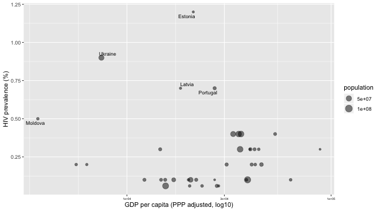

## A time plot of the percentual change of HIV prevalence since 2000, for countries with an exceptionally high level of HIV prevalence

We consider countries with elevated HIV prevalence ( $\ge$ 0.5) relative to the other countries in the continent.

Any point below the horizontal line at zero indicate that HIV prevalence has decreased from the previous year. Points at the horizontal zero-line indicate that HIV prevalence hasn’t changed from the previous year. Points above the horizontal zero-line indicate a growth in HIV prevalence from the previous year.

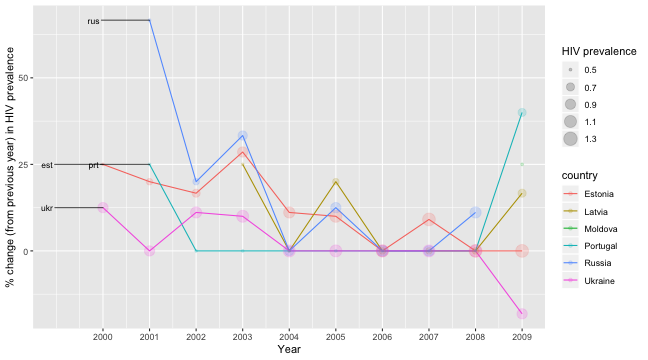

## A map of Europe with countries coloured according to HIV prevalence in 2009.

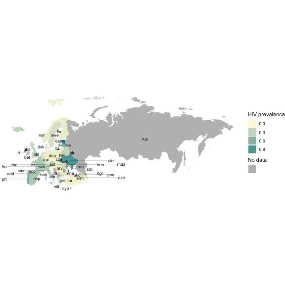

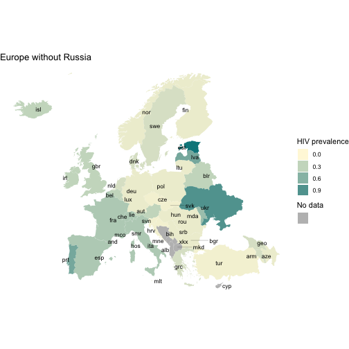

# Tables

| country | 2000 | 2001 | 2002 | 2003 | 2004 | 2005 | 2006 | 2007 | 2008 | 2009 |
| --- | --- | --- | --- | --- | --- | --- | --- | --- | --- | --- |
| Albania |  |  |  |  |  |  |  |  |  |  |
| Andorra |  |  |  |  |  |  |  |  |  |  |
| Armenia | 0.1 | 0.1 | 0.1 | 0.1 | 0.1 | 0.1 | 0.1 | 0.1 | 0.1 | 0.2 |
| Austria | 0.1 | 0.1 | 0.1 | 0.2 | 0.2 | 0.2 | 0.2 | 0.3 | 0.3 | 0.3 |
| Azerbaijan | 0.06 | 0.06 | 0.06 | 0.06 | 0.06 | 0.06 | 0.06 | 0.1 | 0.1 | 0.1 |
| Belarus | 0.1 | 0.1 | 0.1 | 0.1 | 0.2 | 0.2 | 0.2 | 0.2 | 0.2 | 0.3 |
| Belgium | 0.2 | 0.2 | 0.2 | 0.2 | 0.2 | 0.2 | 0.2 | 0.2 | 0.2 | 0.3 |
| Bosnia and Herzegovina |  |  |  |  |  |  |  |  |  |  |
| Bulgaria | 0.06 | 0.06 | 0.06 | 0.06 | 0.1 | 0.1 | 0.1 | 0.1 | 0.1 | 0.1 |
| Croatia | 0.06 | 0.06 | 0.06 | 0.06 | 0.06 | 0.06 | 0.06 | 0.06 | 0.06 | 0.06 |

[output cut: 40 more lines]

[output not shown]